# WHAT MAKE PEOPLE HAPPY?

Studying happiness could help doctors improve their therapies, assist teachers to improve their teaching techniques, and help companies to put forward a better sales plan. In this project, I will analyze HappyDB data to obtain the things that can make most people feel happy in our daily life.

```python
import numpy as np, pandas as pd
import re, time
from sklearn.externals.joblib import Parallel, delayed
from PIL import Image
from wordcloud import WordCloud, STOPWORDS
from matplotlib import pyplot as plt
import seaborn as sns
from sklearn.feature_extraction.text import CountVectorizer, TfidfVectorizer
sns.set()
%matplotlib inline
```

```python
import os
```

```python
import  networkx as nx
```

To start with, I loaded the processed HappyDB text data and checked the structure of this text data.

```python
happy_df = pd.read_csv('processed_moments.csv', sep=',', header=0)
happy_df.head()
```

|  | hmid | wid | reflection_period | original_hm | cleaned_hm | modified | num_sentence | ground_truth_category | predicted_category | id | text |
| --- | --- | --- | --- | --- | --- | --- | --- | --- | --- | --- | --- |
| 0 | 27673 | 2053 | 24h | I went on a successful date with someone I fel... | I went on a successful date with someone I fel... | True | 1 | NaN | affection | 1 | successfully date sympathy connected |
| 1 | 27674 | 2 | 24h | I was happy when my son got 90% marks in his e... | I was happy when my son got 90% marks in his e... | True | 1 | NaN | affection | 2 | son marks examination |
| 2 | 27675 | 1936 | 24h | I went to the gym this morning and did yoga. | I went to the gym this morning and did yoga. | True | 1 | NaN | exercise | 3 | gym morning yoga |
| 3 | 27676 | 206 | 24h | We had a serious talk with some friends of our... | We had a serious talk with some friends of our... | True | 2 | bonding | bonding | 4 | talked friend flaky understood evening hang |
| 4 | 27677 | 6227 | 24h | I went with grandchildren to butterfly display... | I went with grandchildren to butterfly display... | True | 1 | NaN | affection | 5 | grandchildren butterfly display crohn conserva... |

```python
demographic_df = pd.read_csv("rit-public-HappyDB-b9e529e/happydb/data/demographic.csv", sep=',', header=0)
```

Then I remove the null text and check the lengths of the original text data and the processed text data.

```python
print("Number of processed text become null: {}\n".format(happy_df.text.isnull().sum()))
print("Original Text: {}\nProcessed Text: {}".format(
    happy_df.loc[happy_df.text.isnull()].cleaned_hm,
    happy_df.loc[happy_df.text.isnull()].text
))
# remove null text
happy_df_proc = happy_df.loc[~(happy_df.text.isnull())]
# average word length vs. procssed text length

print("Original text statistics:\n{}\n".format(happy_df_proc.cleaned_hm.str.len().describe()))
print("Processed text statistics:\n{}\n".format(happy_df_proc.text.str.len().describe()))
```

```
Number of processed text become null: 1

Original Text: 70487    I WENT TO nan.
Name: cleaned_hm, dtype: object
Processed Text: 70487    NaN
Name: text, dtype: object
Original text statistics:
count    100391.000000
mean         93.018388
std         115.658903
min           6.000000
25%          45.000000
50%          68.000000
75%         105.000000
max        6557.000000
Name: cleaned_hm, dtype: float64

Processed text statistics:
count    100391.000000
mean         41.625395
std          54.246979
min           2.000000
25%          20.000000
50%          31.000000
75%          47.000000
max        3582.000000
Name: text, dtype: float64
```

# I. Wordcloud

Wordcloud is a way to show the frequencies or importances of text through vivid graph. In the graph, we can analyze the frequency of a word by its size. In this part, I will compare results of the original data with results of the processed data to see if there is any difference between them and to determine which one is more reasonable.

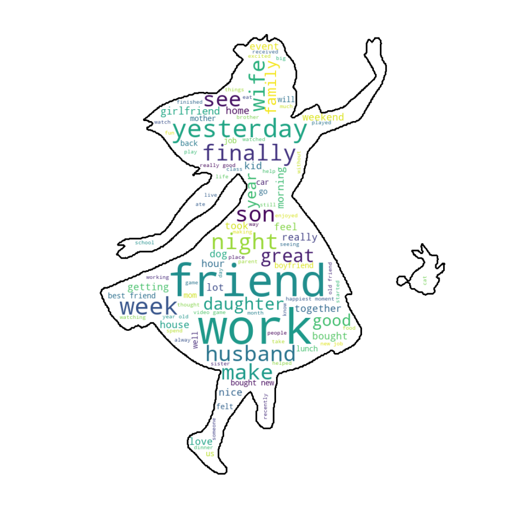

```
<wordcloud.wordcloud.WordCloud at 0x1a1d4ed630>
```

```python
stopwords = set(STOPWORDS)
stopwords.update(set(["one","two","time","last","found","first","now",
                      "since","something","thing","made","long","able",
                      "going", "month", "happy", "saw", "day", "today",
                      "got", "went"]))
alice_mask = np.array(Image.open('alice_mask.png'))
wordcloud = WordCloud(stopwords=stopwords,
                      max_words=100,
                      mask=alice_mask,
                      contour_width=3,
                      background_color='white'
                     ).generate(' '.join(happy_df_proc.cleaned_hm.tolist()))
fig, ax = plt.subplots(figsize=(15, 15))
plt.axis('off')
plt.imshow(wordcloud, interpolation='bilinear')
plt.show()

wordcloud.to_file('Columbia/spring_2019/5243appliedDS/project1/output/wc_happy.png')
```

First, I would like to use wordcloud to visulize the words that are most frequently shown in our data set. This graph is to use the data before we process. As we can see, the most frequent word is "friend", which means most people feel happy when they are with thier friends. The second word is "work", which means when asked about the happy moment, a lot of people talked about their works. Another kind of frequent appear words is about family, such as husband, son, daughter, wife, etc. This is because people tend to be relaxed when they are with their family.

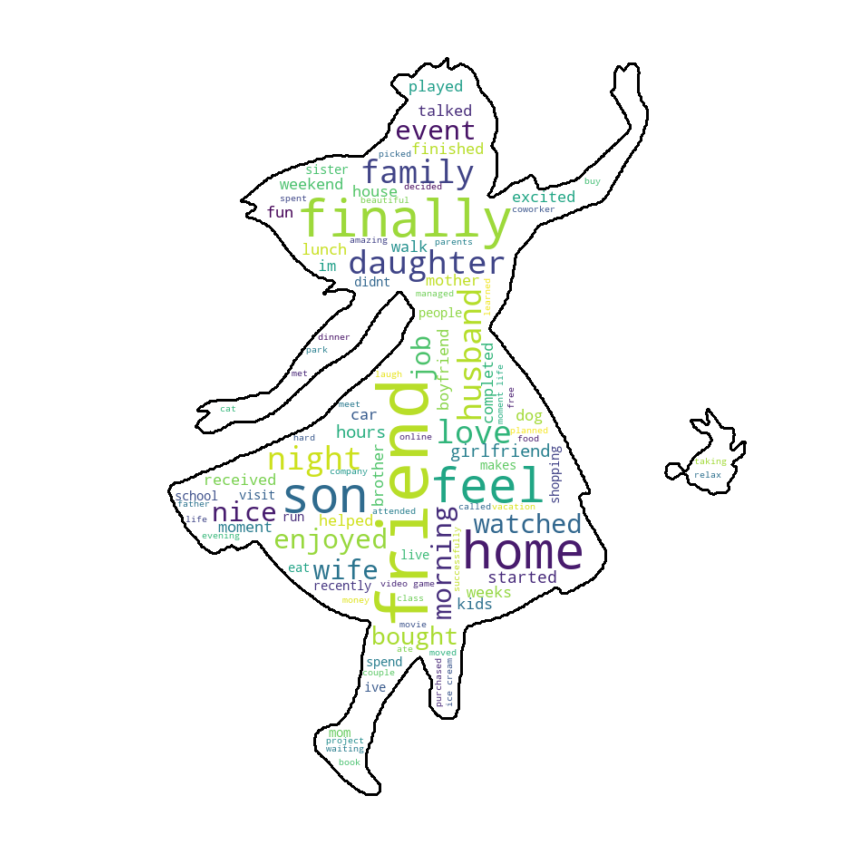

```
<wordcloud.wordcloud.WordCloud at 0x107bf2a58>
```

```python
stopwords = set(STOPWORDS)
stopwords.update(set(["one","two","time","last","found","first","now",
                      "since","something","thing","made","long","able",
                      "going", "month", "happy", "saw", "day", "today",
                      "got", "went"]))
alice_mask = np.array(Image.open('alice_mask.png'))
wordcloud = WordCloud(stopwords=stopwords,
                      max_words=100,
                      mask=alice_mask,
                      contour_width=3,
                      background_color='white'
                     ).generate(' '.join(happy_df_proc.text.tolist()))
fig, ax = plt.subplots(figsize=(15, 15))
plt.axis('off')
plt.imshow(wordcloud, interpolation='bilinear')
plt.show()

wordcloud.to_file('Columbia/spring_2019/5243appliedDS/project1/output/wc_happy2.png')
```

The above graph is what we get by using the data after processing. The most frequent appeard words are about friend, family and love. There exists some samll differences between the graph we get through the data before processing. "Work" does not take such a great part in this graph. The result we get from the data after processing is more reasonable. Since it conforms more with our daily life. Usually, for most part of people, they will enjoy themselves more when they are staying with their family or friends. And some people may feel nervious when they are at work.

# II.CountVectorizer & TfidVectorizer

CountVectorizer can count frequencies of each words in this text, while TfidVectorizer take the words' frequencies in the corpus into consideration.

```python
vectorizer = CountVectorizer(max_features = 2000, stop_words = 'english')
dat_tf = vectorizer.fit_transform(happy_df_proc.text.tolist())
top_20_freq = pd.DataFrame([
    vectorizer.get_feature_names(),
    list(np.asarray(dat_tf.sum(0))[0])]
).T.sort_values(1, ascending=False).head(20)
```

```python
vectorizer_idf = TfidfVectorizer(max_features = 2000, stop_words = 'english')
dat_idf = vectorizer_idf.fit_transform(happy_df_proc.text.tolist())
top_20_freq_idf = pd.DataFrame([
    vectorizer_idf.get_feature_names(),
    list(np.asarray(dat_idf.sum(0))[0])]
).T.sort_values(1, ascending=False).head(20)
```

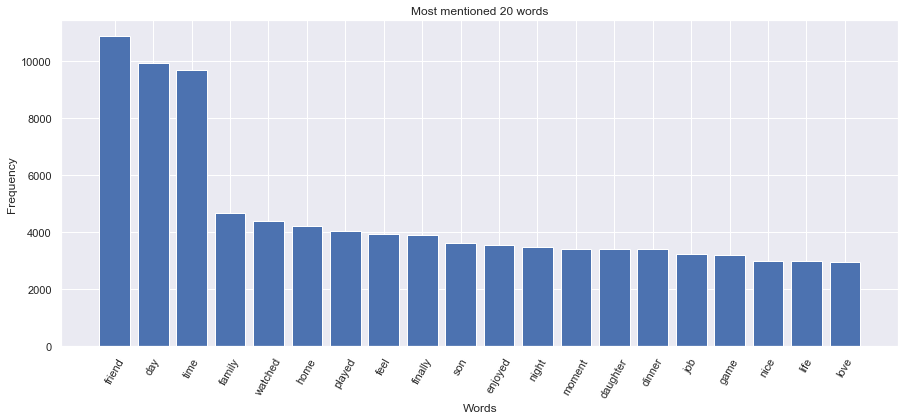

```python
# plot top freq words
fig, ax = plt.subplots(figsize=(15, 6))
ax.bar(top_20_freq[0], top_20_freq[1])
plt.xticks(rotation=60)
plt.xlabel('Words')
plt.ylabel('Frequency')
plt.title('Most mentioned 20 words')
plt.show()
```

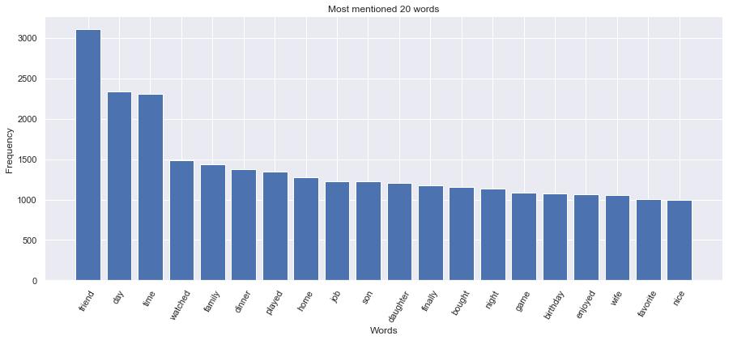

```python
fig, ax = plt.subplots(figsize=(15, 6))
ax.bar(top_20_freq_idf[0], top_20_freq_idf[1])
plt.xticks(rotation=60)
plt.xlabel('Words')
plt.ylabel('Frequency')
plt.title('Most mentioned 20 words')
plt.show()
```

I plot the frequencies of the most mentioned 20 words. There is no abvious difference between these two method. As we can see from the graph above, the most frequent topics are about friend, family and job, which are accord with the conclusion in the above part. What's more, the most popular verbs they mentioned are "watched", "played", "bought". These words are the most common ways people relax themselves.

# iii. textRank

TextRank is a method that learns the relationships between words, and then after calculation, it can get the importance of words. In this part, I will use textRank to get the most important words in our data set.

```python
def buildG(text):

    G = nx.Graph()

    word2id = {}
    id2word = {}
    for sentence in text:
        try:
            tokens = sentence.split()
        except:
            print(tokens)
            continue
        length = len(tokens)
        if len(tokens)>1:
            for i in range(0, length-1):
                w1 = tokens[i]

                if w1 in word2id:
                    w1_idx = word2id[w1]
                else:
                    w1_idx = len(word2id)
                    word2id[w1] = w1_idx
                    id2word[w1_idx] = w1
                    G.add_node(w1_idx)

                for j in range(i+1, length):
                    w2 = tokens[j]
                    if w2 in word2id:
                        w2_idx = word2id[w2]
                    else:
                        w2_idx = len(word2id)
                        word2id[w2] = w2_idx
                        id2word[w2_idx] = w2
                        G.add_node(w2_idx)

                    if not G.has_edge(w1_idx, w2_idx):
                        G.add_edge(w1_idx, w2_idx, weights=1)
                    else:
                        G[w1_idx][w2_idx]['weights'] += 1
    return G, word2id, id2word
```

```python
G, word2id, id2word = buildG(happy_df.text.tolist())
```

```
['wife', 'safe', 'successfully', 'delivery']
```

```python
results = nx.pagerank(G, weight='weights', max_iter=300)
results_sort = sorted(results.items(), key=lambda x: x[1], reverse=True)
```

```python
ranked_kws = list(map(lambda x: (id2word[x[0]], x[1]), results_sort))
ranked_kws
```

```
[('day', 0.012166119229564969),
 ('time', 0.01203472262072249),
 ('friend', 0.0086343239433967),
 ('life', 0.005837923272738485),
 ('family', 0.005756620792032707),
 ('feel', 0.0053919207443694946),
 ('moment', 0.004996141341055263),
 ('home', 0.004695388025843904),
 ('enjoyed', 0.004064755422638075),
 ('finally', 0.003956734656913864),
 ('love', 0.0037969747437211422),
 ('played', 0.003709828827255835),
 ('happiness', 0.0036786505131131356),
 ('watched', 0.003634529767093778),
 ('started', 0.0035991965258949632),
 ('found', 0.003559422578034601),
 ('night', 0.003467774502958469),
 ('school', 0.0030433569854681278),
 ('people', 0.0029680975922866423),
 ('event', 0.0028965521510782304),
 ('walk', 0.0028705662467253543),
 ('son', 0.002807942944390675),
 ('morning', 0.002784451169900279),
 ('game', 0.0027141028179014995),
 ('visit', 0.0026441241552598595),
 ('im', 0.002598436042755185),
 ('nice', 0.002585983049537556),
 ('food', 0.002533814427827944),
 ('hours', 0.002459907203009902),
 ('job', 0.002430966284801343),
 ('live', 0.002406287504944386),
 ('favorite', 0.0023974926787367957),
 ('car', 0.0023753401130862054),
 ('house', 0.002322739329962983),
 ('mother', 0.002260377535171882),
 ('daughter', 0.0022546382789849955),
 ('surprise', 0.002230690167687569),
 ('spend', 0.002203004926616537),
 ('birthday', 0.0021862819419384764),
 ('bought', 0.0021791113342409752),
```

[output cut: 946 more lines]

```
 ('blog', 0.00017915638013730632),
 ('resort', 0.0001783845133639738),
 ('assistant', 0.00017832241806630964),
 ('cheer', 0.00017812413539284504),
 ('diet', 0.00017795366287477835),
 ('kitten', 0.00017779855439879592),
 ('refreshed', 0.0001777372999982824),
 ('low', 0.0001776578793337509),
 ('giggled', 0.0001776123681779771),
 ('sex', 0.00017752609598535506),
 ('bright', 0.00017748919422028205),
 ('promptly', 0.00017685716726025192),
 ('tax', 0.00017681481456961225),
 ('decision', 0.00017658957814944797),
 ...]
```

Here, I list the ranked key words, and there is no obvious difference between the results above. We can see that the most popular topics are still about friend, family, and love, etc.

# iv. lda

Lda is a generative probability model that can discover themes in text and give latent topics along with potential keywords.

```python
from sklearn.pipeline import Pipeline
from sklearn.decomposition import LatentDirichletAllocation as lda
from sklearn.model_selection import GridSearchCV
```

```python
pipeline = Pipeline([
    ("countvectorizor", CountVectorizer(min_df=10)),
    ("lda", lda(max_iter=20, learning_method='batch'))
])

param_grid = {'lda__n_components': [9,12]}


cv = GridSearchCV(pipeline,
                  param_grid,
                  cv=3,
                  n_jobs=4)
```

Since unproper text length has lots of disadvantages to our analysis (Hong and Davison 2010), so we set minimum and maximum length to avoid data noise.

```python
min_words = 20
max_words = 300
lda_text = happy_df_proc.loc[
    (happy_df_proc.text.str.len()>min_words) &
    (happy_df_proc.text.str.len()<max_words)
]
print("Text more than {} words less than {} words: {}\n".format(min_words,
                                                                max_words,
                                                                lda_text.shape[0]))
t1 = time.time()
cv.fit(lda_text.text)
t2 = time.time()
print("Grid search: {:.2f} secs".format(t2-t1))
```

```
Text more than 20 words less than 300 words: 74634

Grid search: 1043.96 secs
```

```python
def print_top_words(model, feature_names, n_top_words):
    for topic_idx, topic in enumerate(model.components_):
        message = "Topic #%d: " % topic_idx
        message += " ".join([feature_names[i]
                             for i in topic.argsort()[:-n_top_words - 1:-1]])
        print(message)
    print()
```

```python
print_top_words(cv.best_estimator_.steps[1][1],
                cv.best_estimator_.steps[0][1].get_feature_names(),
                12)
```

```
Topic #0: started feel found book read day time morning ice lost money cream
Topic #1: time day visit family weekend spend trip planned vacation spent enjoyed mother
Topic #2: received job completed project finished money finally company pay promotion goal boss
Topic #3: played game bought won buy purchased found store shopping video tickets friend
Topic #4: daughter son school moved phone class learned graduation ride finally bike college
Topic #5: dinner favorite food eat ate lunch delicious restaurant cooked husband wife night
Topic #6: watched love night movie day baby time moment life laugh dad girl
Topic #7: car dog home house walk day finally cleaned weather coworker feel nice
Topic #8: friend birthday time family moment day celebrated talked brother life party enjoyed
```

The summarized topics are listed below:

topic 0: time at home topic 1: family time topic 2: job achievement topic 3: shopping topic 4: children's learning topic 5: eat topic 6: entertainment topic 7: home topic 8: time with friends

# v. Category analysis

Finally, I use the demographic data set to analyze the predicted category. In this part, I will check the frequency of different category and the mean word length people describe their happy moment in each category.

```python
merged_df = happy_df_proc.merge(demographic_df, on='wid', how='inner')
merged_df.head(3)
```

|  | hmid | wid | reflection_period | original_hm | cleaned_hm | modified | num_sentence | ground_truth_category | predicted_category | id | text | age | country | gender | marital | parenthood |
| --- | --- | --- | --- | --- | --- | --- | --- | --- | --- | --- | --- | --- | --- | --- | --- | --- |
| 0 | 27673 | 2053 | 24h | I went on a successful date with someone I fel... | I went on a successful date with someone I fel... | True | 1 | NaN | affection | 1 | successfully date sympathy connected | 35 | USA | m | single | n |
| 1 | 27873 | 2053 | 24h | I played a new game that was fun and got to en... | I played a new game that was fun and got to en... | True | 1 | NaN | leisure | 201 | played game fun enjoyed mechanical | 35 | USA | m | single | n |
| 2 | 28073 | 2053 | 24h | I listened to some music and heard an entire a... | I listened to some music and heard an entire a... | True | 1 | NaN | leisure | 401 | listening music heard entire album hadnt heard | 35 | USA | m | single | n |

```python
sns.set()
```

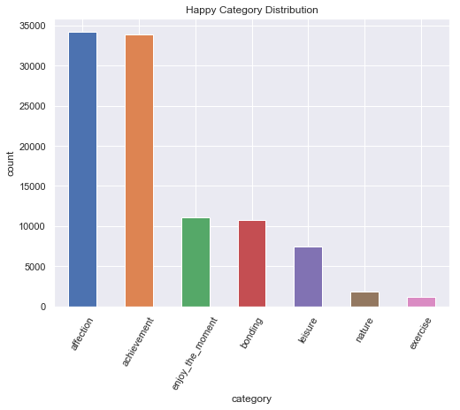

```python
happy_df_proc.predicted_category.value_counts().plot.bar(figsize=(8,6))
plt.xticks(rotation=60)
plt.xlabel("category")
plt.ylabel("count")
plt.title("Happy Category Distribution")
plt.show()
```

In this plot, the most common categories are affection, achievement and enjoy the moment, ect. The arranged category fits our topic closely.

```python
cat_word_dist =  happy_df_proc.copy()
cat_word_dist['length'] = cat_word_dist.text.str.len()
```

[output not shown]

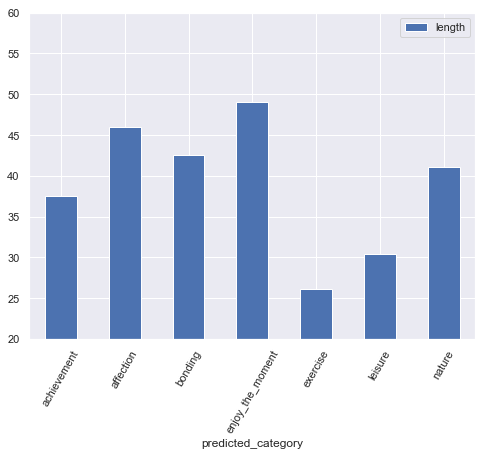

```python
cat_word_dist.pivot_table(
    index="predicted_category",
    values="length",
    aggfunc='mean').plot.bar(figsize=(8,6))
plt.xticks(rotation=60)
plt.ylim(20,60)
```

From the above plot, we can get word length distribution across different category. Enjoy the moment has the most words, while exercise has the least words. In other words, people tend to use more words to describe the way they enjoy the moment, while they use short words to describe exercise.

# vi. Overview

In conclusion, it is importent to learn happy moment in our daily life. For most people, their happy moments are related to friends, family, love and their job. They enjoy their time when they are relaxing or when they have some achievements in their jobs. The research to happy moments can have lots of applications in our life.

# vii. References

A. Asai, S. Evensen, B. Golshan, A. Halevy, V. Li, A. Lopatenko, D. Stepanov, Y. Suhara, W.-C. Tan, and Y. Xu. HappyDB: A corpus of 100,000 crowdsourced happy moments. In Proc. LREC, 2018

D. Blei, A. Ng, and M. Jordan. Latent Dirichlet allocation. Journal of Machine Learning Research, 3:993–1022, 2003.

Hong, L., and Davison, B. D. 2010. Empirical study of topic modeling in twitter. In Proc. First Workshop on Social Media Analytics, SOMA ’10, 80–88. NYC, NY, USA: ACM.

Mihalcea,R.,& Tarau,P. (2004).Textrank:Bringingorderinto texts.In Lin,D.,& Wu,D (Eds.), ProceedingsofEMNLP2004,pp.404{411Barcelona,Spain.AssociationforComputationalLinguistics.